# Meet My Dog Zeke!

Omar Garza

2020-05-11

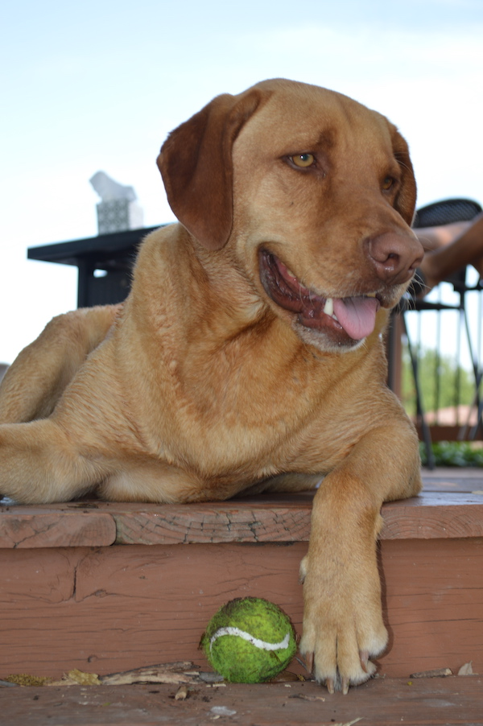

Everyone meet Zeke, my 2 year old fox red laborador. Yes, he has beautiful human eyes and a pink nose, unlike most laboradors. Just as curious as you may be, I had to do some research. Turns out, my son is a certain kind of laborador called Dudley. Dudley is essentially albinism in dogs, most common among laboradors, which they do not have the pigment in their nose to be dark and their eyes tend to be yellow or green.

Zeke comes from a breeder near College Station, TX, where I met him at the young age of just 10 weeks. This boy has not left my side ever since. From the college days of living in an apartment trying to potty train, to the beautiful, hot summers in my family’s pool, Zeke is my most prized possession. I do anything and everything to make my dog feel like he has the world, just as he deserves.

A few of Zeke’s interests include walks or jogs around the neigborhood with his dad, swimming (he’s a big swimmer no matter how cold it is outside), and fetch! He can play fetch all day long to where you may even get tired before he does, true story.

Why the name Zeke you may ask? Well after multiple google searches and asking around, just as any dog owner does, I finally came to my own conclusion. Being an avid Catholic and a man of faith, I wanted to give him a biblical name, but make it sound cool. Flipping through the bible, and doing some more online searches, I came across Ezekiel. In Hebrew, this name means “God strengthens”, and boom I knew that was it. However, as typical dog names are only one syllable, and as you can see where this is going, Zeke comes short for Ezekiel. So no, I am not a big Ezekiel Elliot fan from the Dallas Cowboys, but it’s fine to think that’s the case rather than having me explain the origins of Zeke everytime.